# Red Wine Quality Analysis

# Final Plots and Summary

## Quality, Alcohol and Volatile Acidity

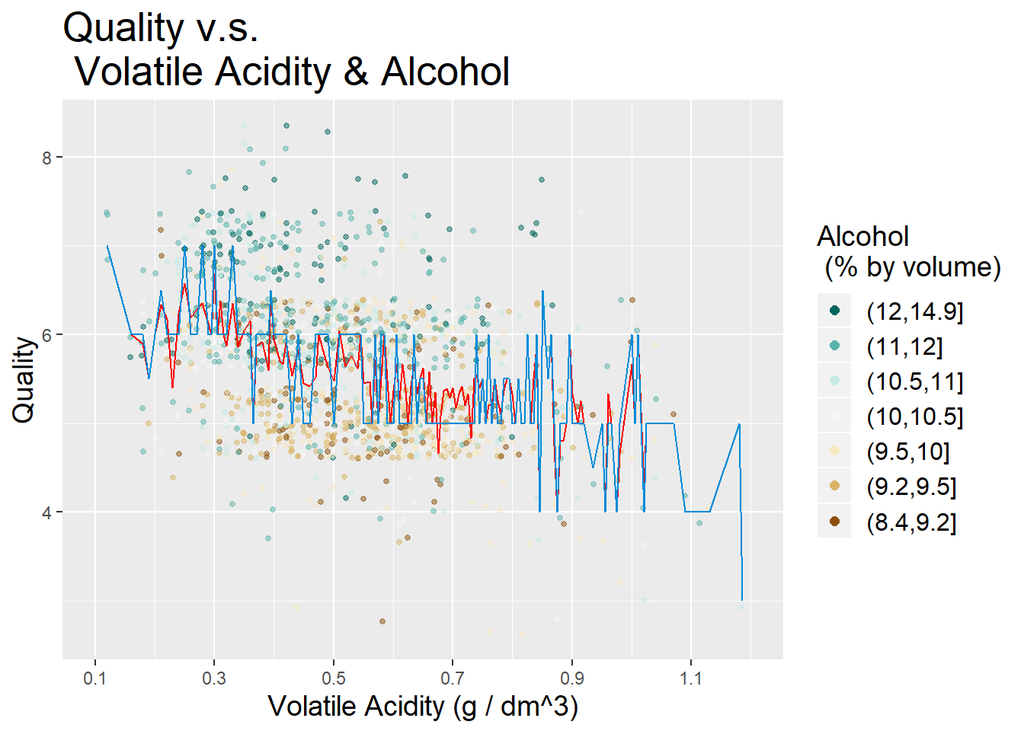

- Alcohol and quality are positively correlated.
- Volatile acidity and quality are negatively correlated.

## Quality, Alcohol and Sulphates

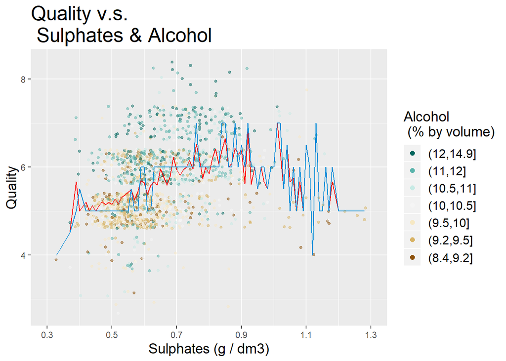

- Alcohol and quality are positively correlated.
- Sulphates and quality are positively correlated.

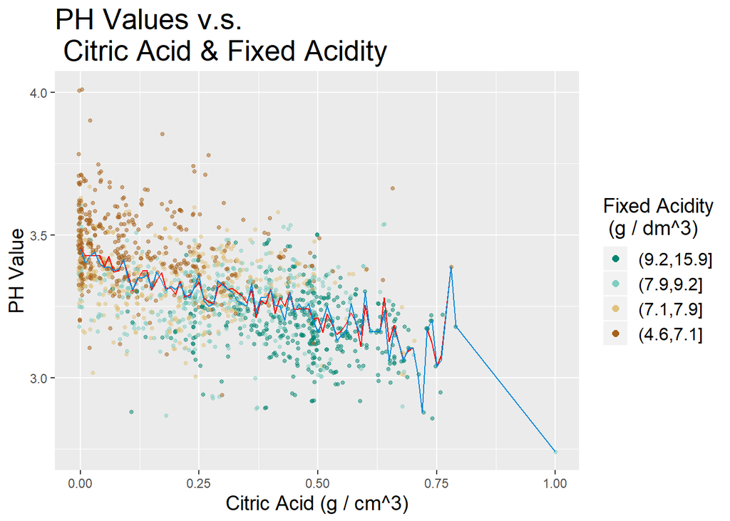

# Reflection

## Conclusion

3 out of 11 chemicals are moderately correlated with quality:

- Volatile Acidity (negatively),
- Sulphates (positively) and
- Alcohol (positively),

while others are not correlated.

Besides, these 3 chemicals are not correlated with each other. Thus, they can be used to predict the quality score.

## Limitation

There are some chemicals highly correlated with each other:

- pH and Fixed Acidity
- pH and. Citric Aciity
- Citric Acid and Fixed Acidity
- Citric Acidity and Volatile Acidity
- Density and Fixed Acidity
- Free Sulfur Dioxide and Total Sulfur Dioxide

To design a better experiment, it would be helpful to drop some of the highly correlated variables.

Besides, the quality scores are mainly between 5-6, and some are 7. It can be noticed that none of the wines were scored 0-2 and 9-10. Usually a 5-point scale would be better for scoring.

It might also be helpful to ask experts to score the acidity and sweetness after tasting (e.g 1-Not sweet at all ~ 5-Too sweet). Then we can compare the degree of real sweetness /sourness and the subjective feeling of it.

## Success and Improvement

I feel it is much more clear to separate the data and the plot function. The code structure is better after gathering data and put it into array-like storage.

I would try more kinds of plots and to add more details for the plots the next time (e.g. I tried to add a layer to show correlation coefficiency on the scatter plot, but I failed.)

[^1]: Information of the Original Data: P. Cortez, A. Cerdeira, F. Almeida, T. Matos and J. Reis. Modeling wine preferences by data mining from physicochemical properties. In Decision Support Systems, Elsevier, 47(4):547-553. ISSN: 0167-9236.